# Texas 2022 Analysis

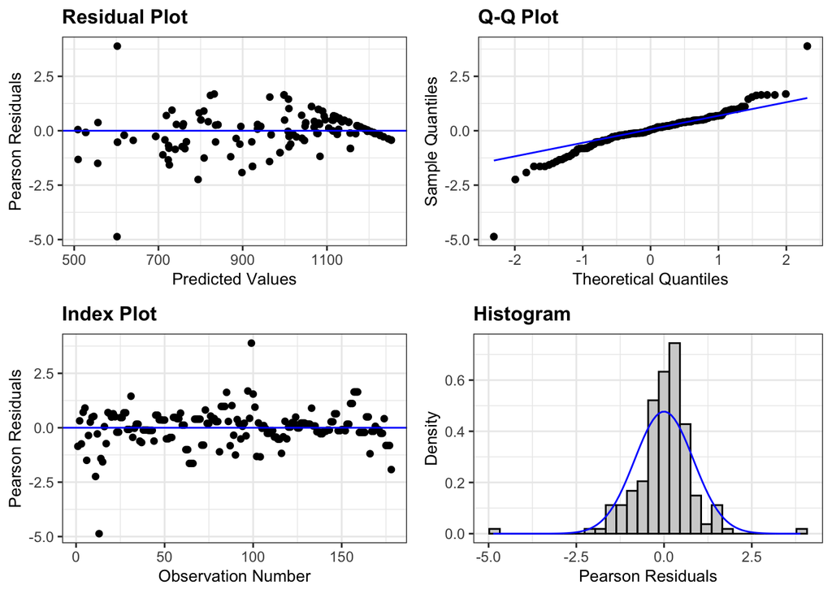

```r
## evaluating assumptions
ggResidpanel::resid_panel(mod_2way)
```

```r
anova(mod_full, mod_2way)
```

```
## refitting model(s) with ML (instead of REML)
```

```
## Data: total_hide_open
## Models:
## mod_2way: duration.Hiding ~ total.parasites:species + total.parasites:trial + species:trial + (1 | fish.ID)
## mod_full: duration.Hiding ~ total.parasites * species * trial + (1 | fish.ID)
##          npar    AIC    BIC  logLik deviance  Chisq Df Pr(>Chisq)
## mod_2way    7 2351.3 2373.6 -1168.7   2337.3
## mod_full   10 2337.7 2369.5 -1158.8   2317.7 19.648  3  0.0002008 ***
## ---
## Signif. codes:  0 '***' 0.001 '**' 0.01 '*' 0.05 '.' 0.1 ' ' 1
```

Ok now I’m going to make a plot to disentangle the pairwise interaction we’ve got going on.

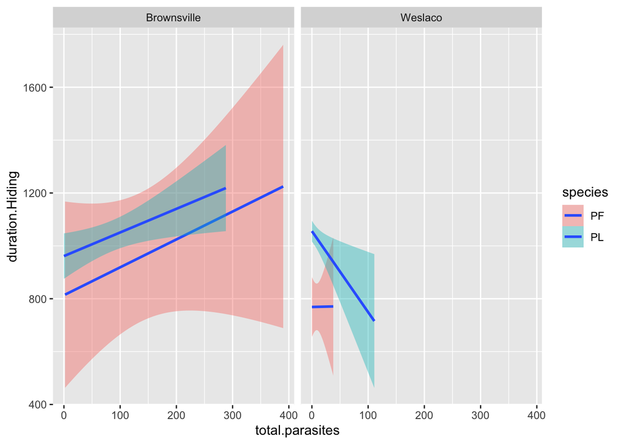

```r
# This plots number of parasites vs time spent hiding. Each line represents a species.
# I've also split the plot into the two sites: Brownsville and Weslaco.
pairwise_species_plot <- total_hide_open %>%
  ggplot(mapping = aes(
    y = duration.Hiding,
    x = total.parasites,
    fill = species
  )) +
  geom_smooth(method = "lm") +
  facet_wrap(vars(site.ID))
pairwise_species_plot
```

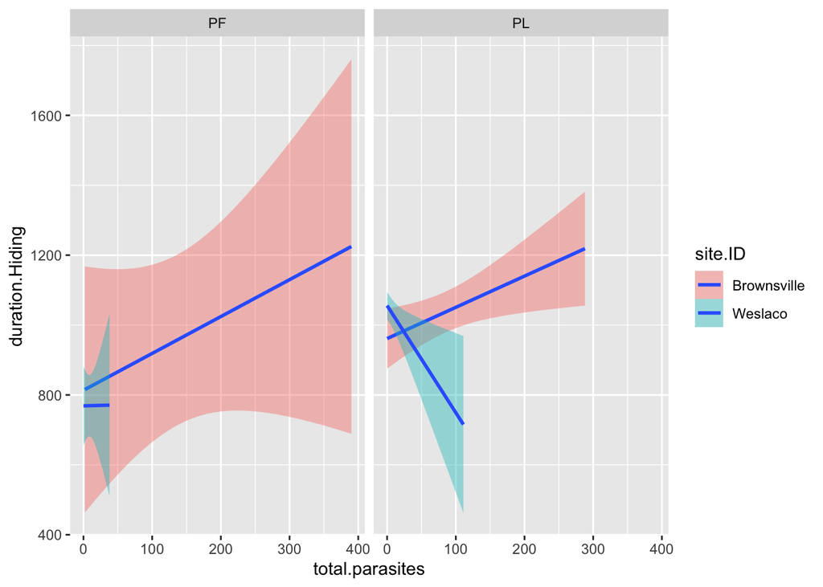

```r
pairwise_site_plot <- total_hide_open %>%
  ggplot(mapping = aes(
    y = duration.Hiding,
    x = total.parasites,
    fill = site.ID
  )) +
  geom_smooth(method = "lm") +
  facet_wrap(vars(species))
pairwise_site_plot
```

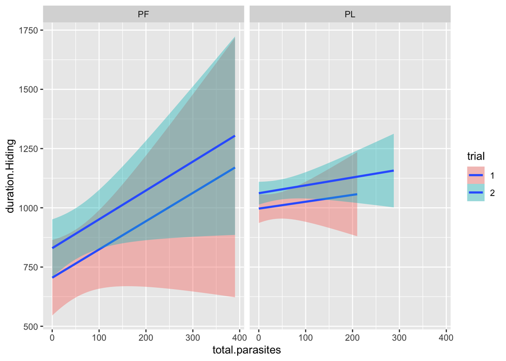

```r
pairwise_trial_plot <- total_hide_open %>%
  ggplot(mapping = aes(
    y = duration.Hiding,
    x = total.parasites,
    fill = trial
  )) +
  geom_smooth(method = "lm") +
  facet_wrap(vars(species))
pairwise_trial_plot
```

```r
# note from Kate: add raw data points
```

### PICK UP HERE

Also, check out how long the trials should be and export the observations from Boris cut off at that length (25 minutes, I think?). Double check that observations that start before the cutoff are assigned a new cutoff at the end trial time and not removed or left longer.

# SCRAPS

### NOTE

There were lots of other plots I made examining site by site or trial by trial patterns as well. They are copied below, but have not been reviewed/error checked.

```r
# change in hiding over trials by species
trial_hiding <- total_hide_open %>%
  ggplot(mapping = aes(
    x = trial.ID,
    y = duration_Hiding,
    fill = species,
    dodge = species
  )) +
  geom_boxplot()

# change in hiding over trials by species
trial_open <- total_hide_open %>%
  ggplot(mapping = aes(
    x = trial.ID,
    y = duration_Open,
    fill = species,
    dodge = species
  )) +
  geom_boxplot()

# diff in open between sites
site_open <- total_hide_open %>%
  ggplot(mapping = aes(
    x = site.ID.x,
    y = duration_Open
  )) +
  geom_boxplot()

# diff in hiding between sites
site_hiding <- total_hide_open %>%
  ggplot(mapping = aes(
    x = site.ID.x,
    y = duration_Hiding
  )) +
  geom_boxplot()
# diff in opn between sites by species
site_spp_open <- total_hide_open %>%
  ggplot(mapping = aes(
    x = site.ID.x,
    y = duration_Open,
    fill = species.x,
    dodge = species.x
  )) +
  geom_boxplot()

# diff in hiding between sites by species
site_spp_hiding <- total_hide_open %>%
  ggplot(mapping = aes(
    x = site.ID.x,
    y = duration_Hiding,
    fill = species.x,
    dodge = species.x
  )) +
  geom_boxplot()

# diff in total parasites by species
parasites_spp <- total_hide_open %>%
  ggplot(mapping = aes(
    x = species.x,
    y = totalpara,
    fill = species.x
  )) +
  geom_boxplot()

# diff in total parasites by site
parasites_site <- total_hide_open %>%
  ggplot(mapping = aes(
    x = site.ID.x,
    y = totalpara
  )) +
  geom_boxplot()

# diff in total parasites by site and spp
parasites_site_spp <- total_hide_open %>%
  ggplot(mapping = aes(
    x = site.ID.x,
    y = totalpara,
    fill = species.x,
    dodge = species.x
  )) +
  geom_boxplot()

# variation in parasites with open beh
parasites_open <- total_hide_open %>%
  ggplot(mapping = aes(
    x = totalpara,
    y = duration_Open,
    color = species.x
  )) +
  geom_point()

# variation in parasites with hiding beh
parasites_hiding <- total_hide_open %>%
  ggplot(mapping = aes(
    x = totalpara,
    y = duration_Hiding,
    fill = species.x
  )) +
  geom_smooth()

# avg length at each site by spp.
length_site <- total_hide_open %>%
  ggplot(mapping = aes(
    x = site.ID.x,
    y = total_length..mm.,
    fill = species.x,
    dodge = species.x
  )) +
  geom_boxplot()
```